# land_cover_exercise

## Model training with implemented improvements (final):

```r
# Create final model specification with more trees
model_final <- parsnip::boost_tree(
  trees = 150,  # Increased trees for final model
  min_n = best_params_improved$min_n,
  tree_depth = best_params_improved$tree_depth,
  learn_rate = best_params_improved$learn_rate,
  loss_reduction = best_params_improved$loss_reduction
) |>
  set_engine("xgboost") |>
  set_mode("classification")

# Final workflow
workflow_final <- workflows::workflow() |>
  add_formula(as.factor(LC1) ~ .) |>
  add_model(model_final)

# Fit on all training data

final_model_fit <- fit(workflow_final, data = train_enhanced)
```

```r
# Prepare test data - only remove LC1 if it exists (it shouldn't in test data)
test_enhanced <- test_data_enhanced |>
  select(-any_of(c("pixelID", "lat", "lon", "LC1")))

# Make predictions
predictions <- predict(final_model_fit, new_data = test_enhanced)

# Check predictions
table(predictions$.pred_class) |> print()
```

```
##
##  1  2  3  4  5  6  7  8  9 10
## 46 63 45 57 71 74 60 63 64 57
```

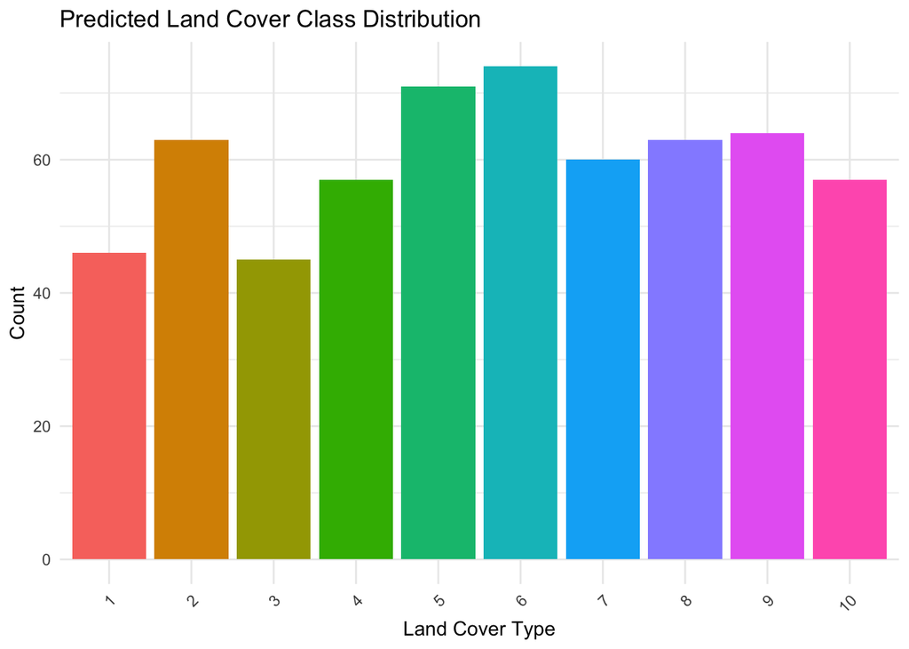

```r
# Visualize predicted class distribution
pred_df <- data.frame(
  land_cover = predictions$.pred_class
)

ggplot(pred_df, aes(x = land_cover, fill = land_cover)) +
  geom_bar() +
  labs(title = "Predicted Land Cover Class Distribution",
       x = "Land Cover Type",
       y = "Count") +
  theme_minimal() +
  theme(axis.text.x = element_text(angle = 45, hjust = 1),
        legend.position = "none")
```

#### comment about the plot We can see here a quite balanced distribution.

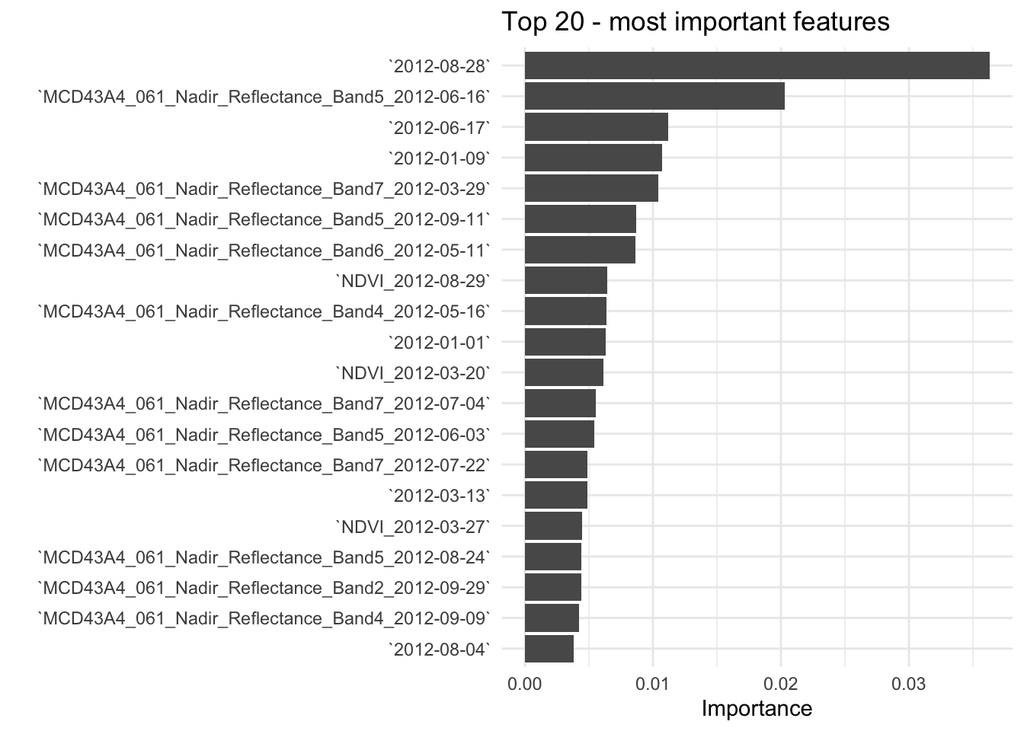

```r
# Extract feature importance from xgboost
vip(final_model_fit, num_features = 20) +
  labs(title = "Top 20 - most important features") +
  theme_minimal()
```

#### comment about the plot We see that it was worth it to add the NDVI indices. The temporal spread of the represented features also suggests that this approach captures phenological patterns: they help to distinguish different type of vegetation.

###submition of the results

```r
# Prepare submission file in the exact format required
submission <- data.frame(
  lulc_class = predictions$.pred_class
)

# Save as CSV
output_file <- "cecber_results.csv"
readr::write_csv(submission, output_file)
```

File saved as output_file, then: 1. Forked into the repository ‘geco-bern/agds2_course’ 2. Results were added as ‘data/leaderboard/fall_2025/cecber_results.csv’ 3. Then they were commited and pushed (the changes) 4. Finally a pull request was main to the main repository